# R Notebook

```r
library(tidyverse)
library(data.table)
library(readtext)
library(lubridate)
library(ggthemes)
```

# Getting data

Data from: http://www.planet4589.org/space/lvdb/list2.html

Name of the fields: http://www.planet4589.org/space/lvdb/launchcols.html

```r
dataG <- read.fwf("http://www.planet4589.org/space/lvdb/lis/G.lis", widths = c(15,11,21,25,7,21,25,25,25,10,9,17,7,2,5,2,13,13,5,25,25,21,21),strip.white=TRUE,col.names=c("ref","id","Launchdate","LV_Type","LV_Variant","Flight_ID","Flight","Mission","flightcode", "Platform", "Launch_Site","Launch_Pad","Apogee","apoflag","Range","rangeflag","Destination","Launch_Agency","Launch_Code","Group","Category","Citation1","Citation2"),na.strings="-")
dataO <- read.fwf("http://www.planet4589.org/space/lvdb/lis/O.lis", widths = c(15,11,21,25,7,21,25,25,25,10,9,17,7,2,5,2,13,13,5,25,25,21,21),strip.white=TRUE,col.names=c("ref","id","Launchdate","LV_Type","LV_Variant","Flight_ID","Flight","Mission","flightcode", "Platform", "Launch_Site","Launch_Pad","Apogee","apoflag","Range","rangeflag","Destination","Launch_Agency","Launch_Code","Group","Category","Citation1","Citation2"),na.strings="-")
dataF <- read.fwf("http://www.planet4589.org/space/lvdb/lis/F.lis", widths = c(15,11,21,25,7,21,25,25,25,10,9,17,7,2,5,2,13,13,5,25,25,21,21),strip.white=TRUE,col.names=c("ref","id","Launchdate","LV_Type","LV_Variant","Flight_ID","Flight","Mission","flightcode", "Platform", "Launch_Site","Launch_Pad","Apogee","apoflag","Range","rangeflag","Destination","Launch_Agency","Launch_Code","Group","Category","Citation1","Citation2"),na.strings="-")
```

```r
data <- rbind(dataG, dataF,dataO)
```

```r
150+344+5267
```

```
[1] 5761
```

```r
 data$Launch_Agency <- gsub("KTRAS/RVSNR", "KTRAS", data$Launch_Agency)
```

Organisation names http://www.planet4589.org/space/lvdb/sdb/Orgs

Documentation:http://www.planet4589.org/space/lvdb/orgs.html

```r
org <- read.fwf('http://www.planet4589.org/space/lvdb/sdb/Orgs',
               widths=c(9,9,7,17,2,13,13,18,81,53,13,11,8,13,17,61,100),skip = 59,col.names=c('code','ucode','parent_code','phase_type','class','start_dates','stop_dates','sname','fullname','location','long','lat','error','parent_org_phase','sname_eng','fullname_eng','region'),strip.white=TRUE,na.strings='-')
```

```r
org
```

| code | ucode | parent_code | phase_type | class | start_dates | stop_dates | sname | fullname | location | long | lat | error | parent_org_phase | sname_eng | fullname_eng | region |
| --- | --- | --- | --- | --- | --- | --- | --- | --- | --- | --- | --- | --- | --- | --- | --- | --- |
| EARTH | EARTH | EARTH | AP |  | NA | NA | Earth | Earth | Earth |  | NA | NA | NA | Earth (Terra) | Earth | Earth |
| LUNA | LUNA | LUNA | AP |  | NA | NA | Luna | Luna | Luna |  | NA | NA | NA | Moon | Moon | Luna |
| AAT | AAT | AAT | CY |  | 1841 | NA | Aus. Antarctic | Australian Antarctic Territory | Davis Staton, Princess Elizabeth Land |  | NA | NA | AU | AAT | Australian Antarctic Territory | Australian Antarctic Territory |
| AF | AF | AF | CY |  | 2004 | NA | Afghanistan | Da Afganistan Islami Jomhoriyat | Afghanistan |  | NA | NA | NA | Afganistan | Afghanistan, Islamic Republic of | \330\257 \330\247\331\201\330\272\330\247\331\206\330\263\330\252\330\247\331\206 \330\247\330\263\331\204\330\247\331\205\331\212 \330\254\331\205\331\207\331\210\330\261\333\214\330\252 |
| AG | AG | AG | CY |  | 1981 | NA | Antigua | Antigua and Barbuda | Antigua |  | NA | NA | NA | Antigua | Antigua and Barbuda | Antigua and Barbuda |
| AGUK | AG | AGUK | CY |  | 1832 | 1981 | Antigua | Antigua colony | Antigua |  | NA | NA | UK | Antigua | Antigua and Barbuda | Antigua colony |
| ANTN | ANTN | ANTN | CY |  | 1954 | 2010 Oct | Ned. Antillen | Nederlandse Antillen | Nederlandse Antillen |  | NA | NA | NL | Neth. Antilles | Netherlands Antilles | Nederlandse Antillen |
| AO | AO | AO | CY |  | 1975 | NA | Angola | Republica de Angola | Luanda |  | NA | NA | NA | Angola | Republic of Angola | Rep\303\272blica de Angola |
| AQ | AQ | AQ | CY |  | NA | NA | Antartica | Antartica | : |  | NA | NA | NA | Antarctica | Antarctica | Antartica |
| AR | AR | AR | CY |  | 1816 Jul 9 | NA | Argentina | Republica Argentina | Argentina |  | NA | NA | NA | Argentina | Argentine Republic | Rep\303\272blica Argentina |

[output cut: 990 more lines]

```r
total = merge(data, org, by.x = 'Launch_Agency', by.y = 'code')
```

```r
anti_join(data,total)
```

| ref | id | Launchdate | LV_Type | LV_Variant | Flight_ID | Flight | Mission | flightcode | Platform | Launch_Site | Launch_Pad | Apogee | apoflag | Range | rangeflag | Destination | Launch_Agency | Launch_Code | Group | Category | Citation1 | Citation2 |
| --- | --- | --- | --- | --- | --- | --- | --- | --- | --- | --- | --- | --- | --- | --- | --- | --- | --- | --- | --- | --- | --- | --- |
| 2011-001 | 2455582 | 2011 Jan 20 1229:02 | Zenit-3SLBF | NA | SB80.1-2007/1/2001 | Elektro-L | Elektro-L | NA | NA | GIK-5 | LC45/1 | NA |  | NA | NA | NA | KVR? | OS | NA | Sat | NK1103-26 | NA |
| 2011-037 | 2455761 | 2011 Jul 18 0231:18 | Zenit-3SLBF | NA | SB80.3/70181-401 | Spektr-R | RadioAstron | NA | NA | GIK-5 | LC45/1 | NA |  | NA | NA | NA | KVR? | OS | NA | Sat | NK1109-39 | NA |
| 2011-056 | 2455840 | 2011 Oct 5 2100:02 | Zenit-3SLB | NA | SB60.5/SLB 5L | Intelsat IS-18 | IS-18 | NA | NA | GIK-5 | LC45/1 | NA |  | NA | NA | NA | SIS/ELUS | OS | NA | Sat | NK1211-28 | sea-launch.com |
| 2013-045 | 2456536 | 2013 Aug 31 2005:00 | Zenit-3SLB | NA | SB60.6/SLB 6L | Amos 4 | Amos 4 | NA | NA | GIK-5 | LC45/1 | NA |  | NA | NA | NA | SIS/ELUS | OS | NA | Sat | NK1310-39 | NA |
| 2015-074 | 2457368 | 2015 Dec 11 1345:32 | Zenit-3SLBF | NA | SB80.4/402/2004 | Elektro-L No. 2 | Elektro-L No. 2 | NA | NA | GIK-5 | LC45/1 | NA |  | NA | NA | NA | KVR? | OS | NA | Sat | Wire | NA |
| 2017-086 | 2458114 | 2017 Dec 26 1900:04 | Zenit-3SLBF | NA | SB80.5/2006 | Angosat | Angosat | NA | NA | GIK-5 | LC45/1 | NA |  | NA | NA | NA | KVR? | OS | NA | Sat | Wire | NA |

```r
#missing launch agency
```

```r
dataO %>% filter(Launch_Agency == "SIS/ELUS")
```

| ref | id | Launchdate | LV_Type | LV_Variant | Flight_ID | Flight | Mission | flightcode | Platform | Launch_Site | Launch_Pad | Apogee | apoflag | Range | rangeflag | Destination | Launch_Agency | Launch_Code | Group | Category | Citation1 | Citation2 |
| --- | --- | --- | --- | --- | --- | --- | --- | --- | --- | --- | --- | --- | --- | --- | --- | --- | --- | --- | --- | --- | --- | --- |
| 2011-056 | 2455840 | 2011 Oct 5 2100:02 | Zenit-3SLB | NA | SB60.5/SLB 5L | Intelsat IS-18 | IS-18 | NA | NA | GIK-5 | LC45/1 | NA |  | NA | NA | NA | SIS/ELUS | OS | NA | Sat | NK1211-28 | sea-launch.com |
| 2013-045 | 2456536 | 2013 Aug 31 2005:00 | Zenit-3SLB | NA | SB60.6/SLB 6L | Amos 4 | Amos 4 | NA | NA | GIK-5 | LC45/1 | NA |  | NA | NA | NA | SIS/ELUS | OS | NA | Sat | NK1310-39 | NA |

# Cleaning data

```r
unique(colnames(total))
```

```
 [1] "Launch_Agency"    "ref"              "id"
 [4] "Launchdate"       "LV_Type"          "LV_Variant"
 [7] "Flight_ID"        "Flight"           "Mission"
[10] "flightcode"       "Platform"         "Launch_Site"
[13] "Launch_Pad"       "Apogee"           "apoflag"
[16] "Range"            "rangeflag"        "Destination"
[19] "Launch_Code"      "Group"            "Category"
[22] "Citation1"        "Citation2"        "ucode"
[25] "parent_code"      "phase_type"       "class"
[28] "start_dates"      "stop_dates"       "sname"
[31] "fullname"         "location"         "long"
[34] "lat"              "error"            "parent_org_phase"
[37] "sname_eng"        "fullname_eng"     "region"
```

```r
total_small <- total %>% select(Launch_Agency, ref, Launchdate, LV_Type, Flight_ID, Flight, Mission, Launch_Site, Launch_Pad, Launch_Code, Category, ucode,parent_code, phase_type, class, sname, fullname,location, sname_eng, fullname_eng)
```

```r
#cleaning unknown agencies
total_small <-  total_small %>% filter(Launch_Agency !="UNK")
total_small <- total_small %>% mutate(Year = str_extract(ref, "[0-9][0-9][0-9][0-9]"))
```

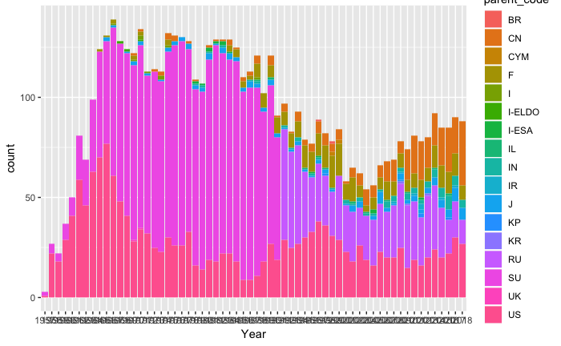

```r
clrs <- c("US"="pink", "SU"="brown", "RU"="brown")
ggplot(total_small, aes(x=Year,fill=parent_code)) +geom_bar()+scale_color_manual(values = clrs)
```

# Private or statal companies?

```r
state <- c("USAF", "U.S. Army Ballistic Missile Agency", "US Air Force Materiel Command","US Air Force Systems Command","United States Army","United States Navy","Agencia Espacial Brasileira","Zhongguo yunzaihuojian jishu yanjiu yuan","Centre Nationale d'Etudes Spatiales","Centro Richerchi Aerospaziale","Centre Europeene de Construct. de Lanceurs et d'Engins Spatiaux","European Space Agency","Hangtian","Federal'noe kosmicheskoe agentstvo Rossii","Sazman Fizaii Iran","Israeli Space Agency","Ucyu Koku Kenkyujyo","Indian Space Research","Ucyu Koku Kenkyu Kaihatsu Kikou","Han-guk Hanggong Uju","Joseon ujugong gangisul","GKNPTs im. M.V. Khrunichev","Kosmichesikiye voyska Rossii","Ministerstvo Voenniy","Gugga Uju Gaebalgug","National Aeronautics and Space Administration","Ucyu Kaihatsu Jigyoudan","Royal Aircraft Establishment","Rossiskoe aviatsionno","Rakentiye Voiska Strategicheskogo Naznacheniye","Shanghai hangtian jishu yanjiuyuan","Space International Services","Upravleniye Nachalnika Kosmicheskikh Sredstv","Voenno-Kosmicheskiye","Voenno-Morskoy ","Voisk Vosdushno-Kosmicheskoi Oborona
MKK Kosmotras)")

private <- c("Arianespace","Boeing Launch Services (?)","EER Systems Inc. Aerospace Div","Energia Logistics Ltd","Eurockot Launch Services GmbH","General Dynamics Commercial Launch","International Launch Services","Beijing lanjian kongjian keji youxian gongsi","Lockheed Martin Astronautics","Lockheed Missiles and Space Co.","McDonnell Douglas Space Systems Corp.","Mitsubishi Jukogyo Kabushiki-kaisha","Martin Marietta","Orbital ATK","Orbital Sciences Corp.","ZAO Puskovie Uslugi","Rocket Lab USA","Rocket Systems Corporation","Sea Launch Limited Partnership","SpaceX","Starsem","United Launch Alliance/Boeing")
```

```r
write.csv(total_small %>% group_by(fullname) %>% count(),"agencies.csv")
```

```r
agencies <- read.csv("agencies.csv", sep = ";")
space <- merge(total_small, agencies, by = "fullname")
```

```r
space <- space %>% mutate(Success = ifelse(Launch_Code == "OF","F","O"))
space <- space %>% select(fullname, Launchdate, Launch_Agency, Mission, parent_code, location, fullname_eng, Year, state, Success)
```

```r
space$parent_code <- gsub(c("SU|RU"),"SU/RU",space$parent_code)
space$parent_code <- gsub(c("CYM|UK"),"CYM/UK",space$parent_code)
```

# Visualisation

```r
space %>% group_by(state) %>% count(state) %>% mutate(n/(953+4801))
```

| state | n | n/(953 + 4801) |
| --- | --- | --- |
| private | 953 | 0.1656239 |
| state | 4801 | 0.8343761 |

```
Using alpha for a discrete variable is not advised.
```

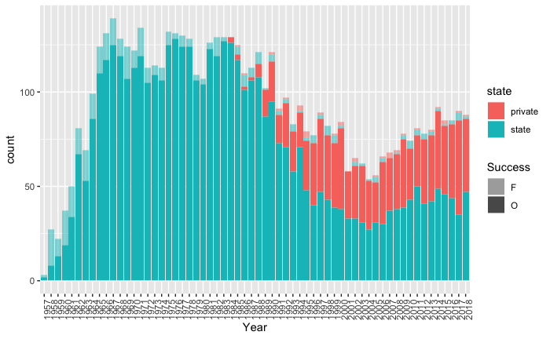

```r
ggplot(space, aes(x=Year, fill=state))+geom_bar(aes(alpha=Success))+
  scale_alpha_discrete(range=c(0.5, 1))+ theme(axis.text.x = element_text(angle = 90))
```

83% of the space battle has been state financially support, mainly by US and USSR.

Mid 80s marks the starting point for private companies. Arianespace came into scene and the presence of private space explorations projects have been increasing since then.

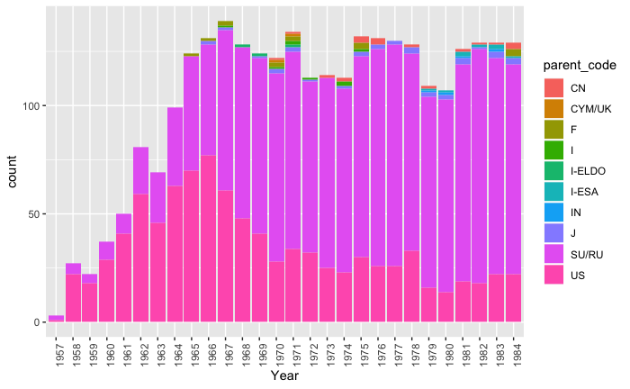

```r
ggplot(space %>% filter(Year<=1984) %>% arrange(desc(Year)), aes(x=Year, fill=parent_code))+geom_bar()+ theme(axis.text.x = element_text(angle = 90))
```

First three decades, the US first and the Soviet Union since mid-65 dominates the battle, with some but little European and Asian influence.

```
Using alpha for a discrete variable is not advised.
```

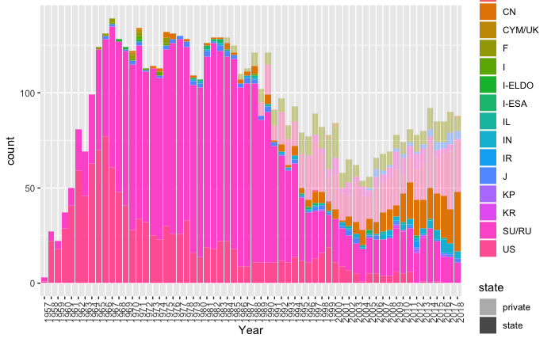

```r
ggplot(space %>% arrange(desc(Year)), aes(x=Year, fill=parent_code))+geom_bar(aes(alpha=state))+ theme(axis.text.x = element_text(angle = 90))+
  scale_alpha_discrete(range=c(0.4, 1))
```

The end of the decade of the 80s the space projects public funded dropped, and it only recovered in the early 2000 when China increases its investement. In the last 10 years, the Chinese agency has been the only one with a significant increase in the rockets.

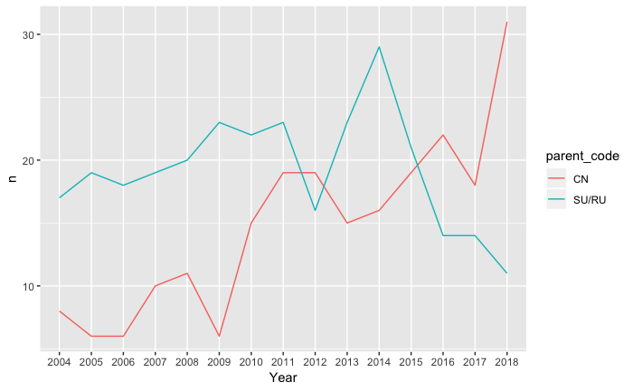

```r
ggplot(space %>% filter(Year > 2003 & state == "state" & parent_code %in% c("CN", "SU/RU")) %>% group_by(parent_code, Year) %>% count(), aes(x=Year, y=n, group=parent_code))+geom_line(aes(color=parent_code))
```

```
Using alpha for a discrete variable is not advised.
```

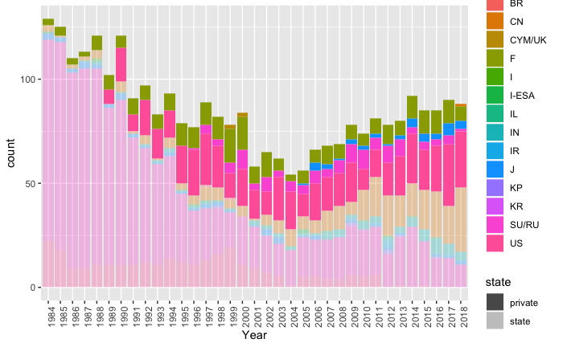

```r
ggplot(space %>% filter(Year >=1984) %>%arrange(desc(Year)), aes(x=Year, fill=parent_code))+geom_bar(aes(alpha=state))+ theme(axis.text.x = element_text(angle = 90))+
  scale_alpha_discrete(range=c(1, .3))
```

As for the number of project privately supported, these have been increasing since the late 80s, with a reducton 2001-2005 and 2010. The US and France (Europe?) dominates these battle, although the Russian adn Japanese presence is remarkable.

```r
write.csv(space, "spacedata.csv")
```